# R Notebook

This script downloads and wrangles data from the CDC/Our World in Data to update (i) the vaccination tool, and (ii) the graphs for the vaccine stockpile report.

```
[1] "/Users/aligo/git-repos/FEMA/vaccinations"
```

Calculate daily history

```
[1] "Latest data from 2021-04-26"
```

```
[1] "Total Administered Connecticut 3094177"
[1] "Total Delivered Connecticut 3716115"
[1] "People with 1+ Doses Connecticut 1897401"
[1] "People with 2+ Doses Connecticut 1298869"
[1] "Total Administered per 100k Connecticut 86790"
[1] "Total Delivered per 100k Connecticut 104230"
[1] "People with 1+ Doses per 100k Connecticut 53220"
[1] "People with 2+ Doses per 100k Connecticut 36430"
[1] "Total Administered Maine 1108830"
[1] "Total Delivered Maine 1265690"
[1] "People with 1+ Doses Maine 699989"
[1] "People with 2+ Doses Maine 487794"
[1] "Total Administered per 100k Maine 82490"
[1] "Total Delivered per 100k Maine 94160"
[1] "People with 1+ Doses per 100k Maine 52070"
```

[output cut: 33 more lines]

CDC population numbers

| location | m | s1 | m2 | s2 |
| --- | --- | --- | --- | --- |
| Connecticut | 3565349.9 | 696.4853 | 3565339.3 | 474.34538 |
| Maine | 1344114.1 | 299.6792 | 1344211.1 | 166.76276 |
| Massachusetts | 6892849.5 | 2000.6293 | 6892524.9 | 943.96096 |
| New Hampshire | 1359705.0 | 305.9258 | 1359717.1 | 184.94462 |
| Rhode Island | 1059297.7 | 299.2806 | 1059362.7 | 141.21454 |
| Vermont | 624017.7 | 118.8929 | 623987.7 | 78.14032 |

Plot daily_vaccinations (it is already 7-day smoothed in the original data)

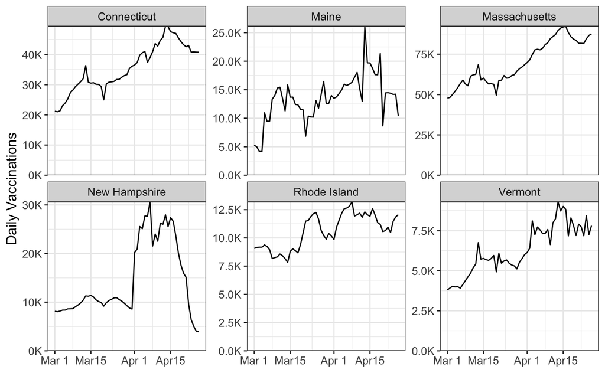

Plot distribution in the last weeks

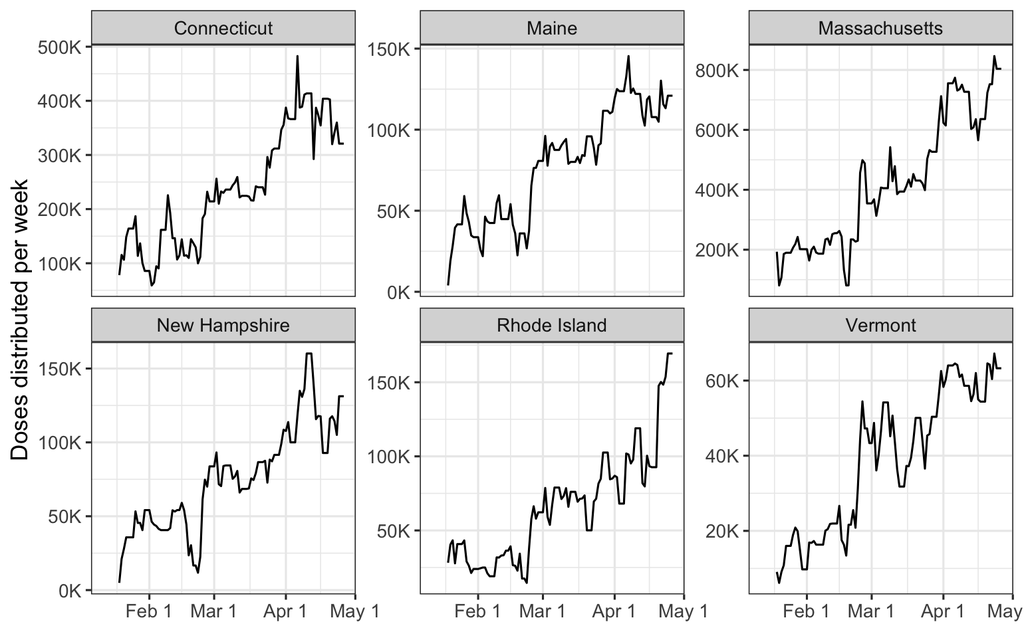

Forecasting:

```
[1] "Latest data from 2021-04-26"
```

Forecasts

```
[1] "Latest data from 2021-04-26 Forecast Cumulative number of doses **distributed**"
[1] "location Connecticut alpha 0.917669254669645 beta 0.0574922571765566 level 3720426.94590041 trend 45303.4468054668"
[1] "location Maine alpha 0.888956895766698 beta 0.0822645424735194 level 1267707.88239059 trend 14968.3149953031"
[1] "location Massachusetts alpha 1 beta 0.065279810137913 level 6771230 trend 90107.6599498143"
[1] "location New Hampshire alpha 1 beta 0.0899730306341363 level 1227615 trend 15267.0997379827"
[1] "location Rhode Island alpha 0.610137204223073 beta 0.101217329026553 level 1074397.2291159 trend 17511.5830134012"
[1] "location Vermont alpha 0.940994004417202 beta 0.06324585072204 level 634147.935655902 trend 7592.89415682552"
[1] "Latest data from 2021-04-26 Forecast Cumulative number of doses **administered**"
[1] "location Connecticut alpha 1 beta 0.160605466772213 level 3094177 trend 43141.8086421196"
[1] "location Maine alpha 0.525003246789473 beta 0.128947717992288 level 1117956.65407428 trend 13600.5111404496"
[1] "location Massachusetts alpha 1 beta 0.18060150036848 level 5855519 trend 89435.5007570095"
[1] "location New Hampshire alpha 0.958870261138442 beta 0.227980275159453 level 1130043.76661833 trend 5554.85268842955"
[1] "location Rhode Island alpha 1 beta 0.200426744512462 level 872064 trend 12376.3977317068"
[1] "location Vermont alpha 0.865504082171126 beta 0.127637296297852 level 536902.246443301 trend 8178.00410066686"
[1] "Latest data from 2021-04-26 Forecast **Daily** number of doses **administered**"
[1] "location Connecticut alpha 1 beta 0.00383271146219168 level 40782 trend 125.267462344314"
[1] "location Maine alpha 0.532296728647898 beta 0.0274715299348079 level 12212.2305331111 trend -42.8366385821731"
[1] "location Massachusetts alpha 0.961751377254627 beta 0.0606060436566976 level 87582.9440484993 trend 542.451939997781"
[1] "location New Hampshire alpha 0.895744225566281 beta 0.158781306601164 level 3732.15669664774 trend -1547.52800296303"
[1] "location Rhode Island alpha 1 beta 0.00375249985132611 level 12050 trend 50.9677447990751"
[1] "location Vermont alpha 0.660281331043328 beta 0.0680589814051515 level 7732.50281132387 trend 23.0457593961599"
[1] "Latest data from 2021-04-26 Forecast people vaccinated per capita"
[1] "location Connecticut alpha 1 beta 0.136029146142896 level 53.22 trend 0.614709319494645"
[1] "location Maine alpha 0.804684479161625 beta 0.0997179916234112 level 52.1982561681444 trend 0.554208332125333"
[1] "location Massachusetts alpha 1 beta 0.190702565457367 level 53.64 trend 0.698164517464336"
[1] "location New Hampshire alpha 0.92584051482687 beta 0.228137411125209 level 59.5510864467483 trend 0.268651404556226"
[1] "location Rhode Island alpha 1 beta 0.222331901417344 level 50.68 trend 0.744353292389793"
[1] "location Vermont alpha 0.846279994153712 beta 0.132948562692796 level 52.6003476584525 trend 0.747634578775572"
```

Bind history and prediction

Plot Forecasted Cumulative number of doses distributed & administered

```
[1] "'Availability' = [Cumulative number of doses distributed] - [Cumulative number of doses administered] - [waste(0.7% of total)]"
```

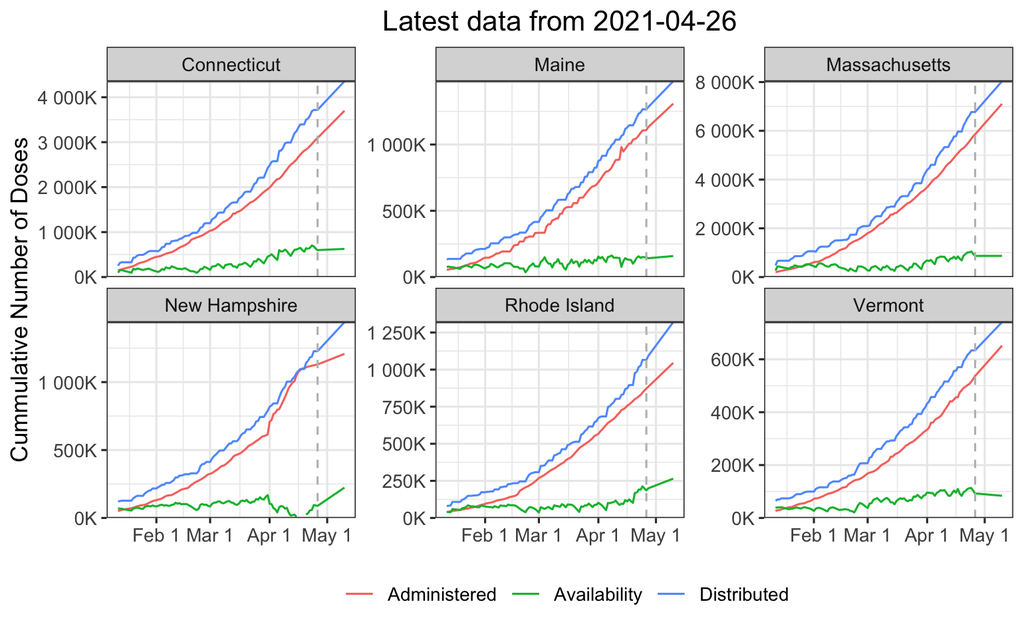

Plot Forecasted Cumulative number of people vaccinated per hundred

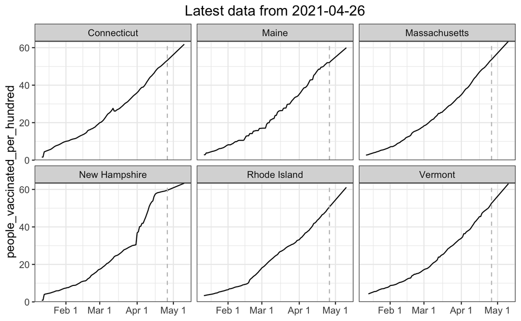

## MAXIMUM CAPACITY

```
Unknown or uninitialised column: `cap`.
```

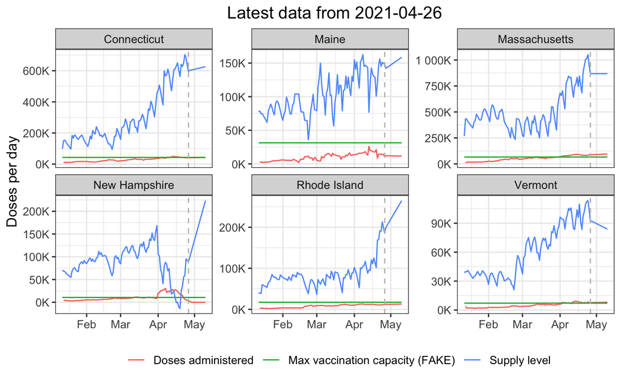

## calculate derivative of daily_vaccinations and totals per 100K people

```
[1] "Latest data from 2021-04-26"
```

# WEEKLY REPORT STARTS HERE

# FEMA-R1 Vaccine Assessment

```
[1] "Latest data from 2021-04-26"
```

## 7-day forecast of dose availability and administration

| location | daily_available | demand2nd | dvac | demand1st | dav | distrib |
| --- | --- | --- | --- | --- | --- | --- |
| Connecticut | 595925.19 | 171009.14 | 288981.489 | 117972.35 | 613118.56 | 306174.85 |
| Maine | 148000.17 | 60627.14 | 84286.188 | 23659.04 | 149718.45 | 86004.47 |
| Massachusetts | 868312.39 | 385890.86 | 628269.263 | 242378.41 | 868602.23 | 628559.10 |
| New Hampshire | 89140.70 | 116774.57 | 2821.729 | 0.00 | 156215.57 | 69896.60 |
| Rhode Island | 185664.71 | 48454.57 | 85777.097 | 37322.53 | 229900.68 | 130013.07 |
| Vermont | 91689.52 | 30354.00 | 54772.801 | 24418.80 | 88338.83 | 51422.11 |

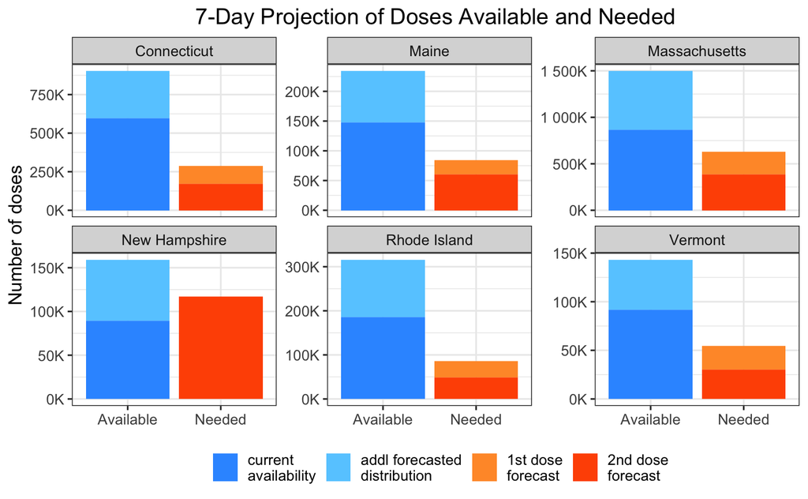

Figure 1. 7-day forecast of availability and administration of doses for the New England states. Source: CDC/Our World in data

# CALCULATIONS for Shiny App

```r
# capacity assumptions
sc <- left_join(sites, sitecap, by=c('date','location','type'))

# main dataframes
colors <- c('daily_vaccinations','cap')
cnames <- c('Doses administered','Max vaccination capacity')
dp <- dfw %>% filter( date <= (latest_history_date+14) ) %>%
    tidyr::pivot_longer( cols = all_of(colors), names_to="s"
                         , values_to = "value",  values_drop_na = TRUE )
dp <- dp %>% mutate( n = NA )
dp$n[dp$s %in% colors] <- cnames[match(dp$s,colors)]

# per capita values per state and Region 1 average
dpp <- data.frame()
for( var in c('total_vaccinations_per_hundred','people_vaccinated_per_hundred') ){
  tmp <- dfw %>% select( c('date','location',all_of(var)) ) %>%
                       tidyr::pivot_wider( names_from='location', values_from=all_of(var) ) %>%
                       mutate( avgr1 = (.[[2]]+.[[3]]+.[[4]]+ .[[5]]+ .[[6]]+ .[[7]]) /6 ) %>%
                       tidyr::pivot_longer( cols=all_of(NEstates), names_to="location"
                                            , values_to = "value",  values_drop_na=FALSE ) %>%
                       tidyr::pivot_longer( cols=c(value,avgr1), names_to="type"
                                            , values_to=var, values_drop_na=FALSE )
  if ( nrow(dpp) == 0 )
    dpp <- tmp
  else
    dpp[,var] <- tmp[,var]
}
dpc <- dpp %>% filter( date <= (latest_history_date+14) )

# Perc people vaccinated over 16 yr old
perc_pop_over16 <- data.frame( state = NEstates,
                               perc_over16 = c(.821, .837, .827, .836, .83, .84) )
for ( st in NEstates ){
  idx <- dpp$location == st
  dpp$people_vaccinated_per_hundredover16[idx] <- dpp$people_vaccinated_per_hundred[idx] / perc_pop_over16$perc_over16[perc_pop_over16$state==st]
}
```

```
Unknown or uninitialised column: `people_vaccinated_per_hundredover16`.
```

```r
# dates where given vars will exceed given percentages of population
calc_threshold_dates <- function(st, vartype){
  tmp <- lapply( c('people_vaccinated_per_hundred','people_vaccinated_per_hundredover16'), function(colref){
    thrs <- c(70, 90)
    dates <- sapply( thrs, function(threshold){
      datetmp <- dpp %>% filter( type==vartype & location==st & !!as.symbol(colref)>=threshold )
      stopifnot( nrow(datetmp) > 0 )
      return( min( datetmp$date ) )
    } )
    return( data.frame( location=st, type=vartype, colref, threshold=thrs, date=as.Date(dates) ) )
  } ) %>% bind_rows()
}
datesdf <- lapply( NEstates, calc_threshold_dates, 'value' ) %>% bind_rows() %>% tidyr::pivot_wider( names_from=colref, values_from=date )
datesdfavg <- calc_threshold_dates( 'Connecticut', 'avgr1' )

# forecasted growth in daily vaccinations
dvacgr <- dfw %>% group_by( location ) %>%
                summarise( b = last(dd_vaccinations), .groups='drop_last' )
```

test only

```r
tmp <- dpp %>% filter( type=='value' & location==NEstates[4]  )
tmp
```

[output not shown]

## SAVE data for Shiny App app.R and for in-transit graph of pre_proc_Tiberius.Rmd

```
[1] "SAVING Latest data from 2021-04-26"
```

## 14-day forecast of availability and administration of doses

| location | daily_available | demand2nd | dvac | demand1st | dav | distrib |
| --- | --- | --- | --- | --- | --- | --- |
| Connecticut | 595925.19 | 342018.29 | 584101.084 | 242082.80 | 626030.15 | 614206.0 |
| Maine | 148000.17 | 121254.29 | 166473.380 | 45219.09 | 158559.63 | 177032.8 |
| Massachusetts | 868312.39 | 771781.71 | 1283118.670 | 511336.96 | 868892.07 | 1283698.3 |
| New Hampshire | 89140.70 | 233549.14 | 2821.729 | 0.00 | 223453.21 | 137134.2 |
| Rhode Island | 185664.71 | 96909.14 | 174051.613 | 77142.47 | 264988.91 | 253375.8 |
| Vermont | 91689.52 | 60708.00 | 110674.844 | 49966.84 | 83871.01 | 102856.3 |

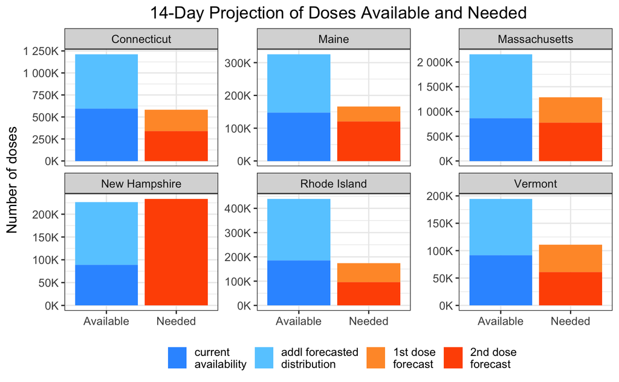

Figure 2. 14-day forecast of availability and administration of doses for the New England states. Source: CDC/Our World in data.

## Forecasting method

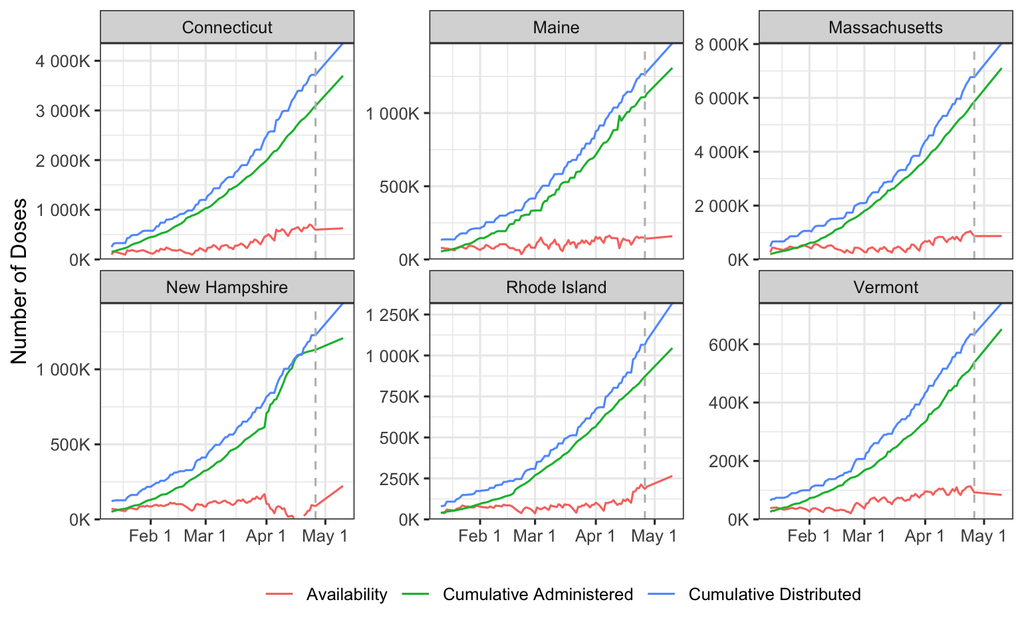